# Practica Notebook - Jorge Oliva

En esta practica, consideraremos datos de un artculo reciente: Vidal, Y.; Aquino, G.; Pozo, F.; Gutierrez-Arias, J.E.M. Structural Health Monitoring for Jacket-Type OshoreWind Turbines: Experimental Proof of Concept. Sensors 2020, 20, 1835, En el que se considera una turbina eolica a escala y el objetivo es poder detectar problemas estructurales en condiciones lo mas realistas posibles.

In this point we are going to import the data :

```r
#install.packages ("R.matlab")
library (R.matlab )
#We import the data2
data <- readMat ('TurbinesData/data_tower_v42m.mat')
```

1. [10 %] Escalar los datos de la matriz tal y como se explica en la Seccion 2.1 del modulo. Llamar a la matriz resultante X.

Answer : We are goin to SCALE the matrix that we have in data$Y and save in X. with the argument center=TRUE, we are going substract to each item the mean of its colum, with the argument scale=TRUE we divide by standard desviation each result of the previous sentence we print the previos and posterior data to scale to see the differences

```r
data$Y[1:5,1:5]
```

```
              [,1]         [,2]          [,3]         [,4]          [,5]
[1,]  0.0003183557 2.463096e-04 -9.071952e-05 2.621842e-04 -0.0001450594
[2,]  0.0003940651 2.426462e-04  7.225464e-04 4.245931e-04  0.0003824645
[3,] -0.0001346798 9.428016e-05 -1.444488e-04 2.833968e-05  0.0003824645
[4,]  0.0001980754 2.786693e-04  6.069936e-05 3.354514e-04 -0.0001505544
[5,]  0.0004154347 4.923653e-04  7.164408e-04 2.878277e-04  0.0003055339
```

```r
X<-scale(data$Y,center  = TRUE,scale = TRUE)
X[1:5,1:5]
```

```
            [,1]       [,2]       [,3]       [,4]       [,5]
[1,]  0.51711989  0.2728762 -1.1844687  0.3114625 -1.4665089
[2,]  0.85812155  0.2551831  2.1621197  1.0385974  0.7939389
[3,] -1.52339002 -0.4613866 -1.4055647 -0.7355023  0.7939389
[4,] -0.02463274  0.4291651 -0.5613802  0.6394933 -1.4900552
[5,]  0.95437201  1.4612614  2.1369951  0.4262733  0.4642903
```

2. [10 %] Calcular la matriz de covarianzas tal y como se explica en la Seccion 2.2 del modulo. Llamar CX a la matriz de covarianzas. >Os ha sido posible el calculo de la matriz de covarianzas? O habeis tenido un error por falta de memoria? En este caso, ir al problema 4. Os haya salido o no el calculo de la matriz de covarianzas, buscar la manera de calcular CX[2,3].

Answer : We can’t calculate the covariancewe, we made the second options covariance of colum 2 and 3

```r
CX<-cov(X[,2:3])
CX
```

```
             [,1]         [,2]
[1,]  1.000000000 -0.003781788
[2,] -0.003781788  1.000000000
```

3. [10 %] Si habeis podido calcular la matriz de covarianzas, calcular sus valores propios y sus vectores propios. Llamar P a la matriz que tiene por columnas los vectores propios de la matriz de covarianzas, ordenados segun la magnitud de los valores propios. >Os ha sido posible el calculo de los valores y de los vectores propios? >O habeis tenido un error por falta de memoria? Justicar vuestra respuesta. En este caso, ir al problema 4.

Answer : We can’t calculate the covariance, because the computer can’t allocate 25 GB, how alternative we get the covariance between the column 2 and 3, the points more important is that they have a lower correlation -0.003781788 , the diagonal items al equal to 1, this is because our data are normalized (scale) the variance are 1. In conclusion, we have a correlation but this is not mean that we have a causal relation

```r
CX<-cov(X)
```

```
Error: cannot allocate vector of size 25.1 Gb
```

```r
CX<-cov(X[,2:3])
CX
```

```
             [,1]         [,2]
[1,]  1.000000000 -0.003781788
[2,] -0.003781788  1.000000000
```

```r
eigCx<-eigen(CX)
eigCx
```

```
eigen() decomposition
$values
[1] 1.0037818 0.9962182

$vectors
           [,1]       [,2]
[1,] -0.7071068 -0.7071068
[2,]  0.7071068 -0.7071068
```

4. [10 %] Calcular directamente el analisis de componentes principales con la instruccion prcomp, llamando a la estructura resultante pca:

```r
pca <- prcomp (X, center=TRUE, scale = TRUE )
```

pca.rotation es la matriz P que tiene por columnas los vectores propios de la matriz de covarianzas, ordenados segun la magnitud de los valores propios. Cual es la dimension de pca.rotation que obteneis y cual es la dimension teorica que debera tener esta matriz? Que esta pasando?

Answer: The dimension of pca.rotation is 58008 x 328 The theoric dimension for a pca.rotation is a matrix of mxm dimension(58008X58008), for memory reason I can’t obtain the covariance matrix, in consequence, I use the instruction prcomp ,than I think that is an algorithm that made some kind of reduction of m (l<m), and this is compatible with the perspective that why we are using the PCA: reduce the dimensionality and identify the variable more relevant.

```r
dim(pca$rotation)
```

```
[1] 58008   328
```

5. [10 %] Considerar vuestra fecha de nacimiento en la forma aammdd, por ejemplo 760827. Calcular, con R lo siguiente 81 + aammdd % % 10 y llamar al resultado S. >Cuantas componentes principales N son necesarias para retener un porcentaje de variabilidad igual o superior al S %? >Que porcentaje de reduccion representa trabajar con S componentes principales en lugar de todos los datos?

Answer: We use summary(pca) to identify that We need 47 components (from PC1 to PC47) to have a accumulative variability equal or greater than S(81).we are going to prove that this is correct calculating the eigenvalues. In the next point to obtain the percentage of reduction we have how data provide that 19026624 as a Total and if we use the 47 components we have 2726000 and this represents a reduction of 85.67%

```r
S<-81 + 720930 %% 10
S
```

```
[1] 81
```

```r
N<-47
eigenvalues<-(pca$sdev)^2
variance<-eigenvalues[1:N]*100/sum(eigenvalues)
accumulative<-cumsum(variance)
accumulative
```

```
 [1]  9.196745 18.050648 25.479986 32.747035 35.772527 38.764249 41.633733 44.477323 47.126356
[10] 49.719082 51.745168 53.696949 55.632097 57.479770 59.303916 60.621166 61.796567 62.940972
[19] 64.031988 65.064810 66.087686 67.071009 68.024681 68.920715 69.782623 70.531797 71.271329
[28] 71.962602 72.641542 73.311746 73.953516 74.593597 75.194400 75.745961 76.248110 76.744707
[37] 77.235195 77.707060 78.152702 78.566047 78.978424 79.385570 79.781971 80.172106 80.553246
[46] 80.927546 81.297050
```

6. [10 %] Representar graficamente | en un unico grafico | los 328 puntos formados por la proyeccion de los datos originales normalizados sobre la primera y la segunda componentes principales. Utilizar un color diferente para cada uno de los cuatro estados estructurales (saludable, da~no en el nivel 1, da~no en el nivel 2 y da~no en el nivel 3). >Observais algo? > En que disposicion geometrica se encuentran los puntos?

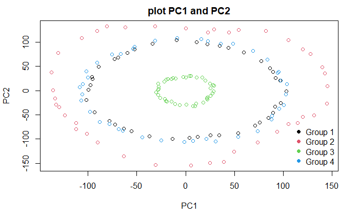

```r
TRANS<-X%*%pca$rotation[,1:2]

plot(TRANS[,1],
     TRANS[,2],
     col = rep(1:4, each = 82),
     xlab="PC1",
     ylab="PC2",
     main = "plot PC1 and PC2")
legend("bottomright", legend = paste("Group", 1:4), col = 1:4, pch = 19, bty = "n")
```

```r
NA
NA
```

7. [10 %] Representar gracamente | en un unico graco | los 328 puntos formados por la proyeccion de los datos originales normalizados sobre la primera y la tercera componentes principales. Utilizar un color diferente para cada uno de los cuatro estados estructurales (saludable, da~no en el nivel 1, dano en el nivel 2 y da~no en el nivel 3). >Observais algo? >En que disposicion geometrica se encuentran los puntos?

Answer: The data shows , a equal distribution in the PC1 axis and some differences in the axis PC3 , the group red which means damage structure in the level 1 is in the top and the bottom of the axis PC3 in the range +- from 100 to 200.the others groups are in the middle of the axis PC3 in the range approximately from -50 to +50.

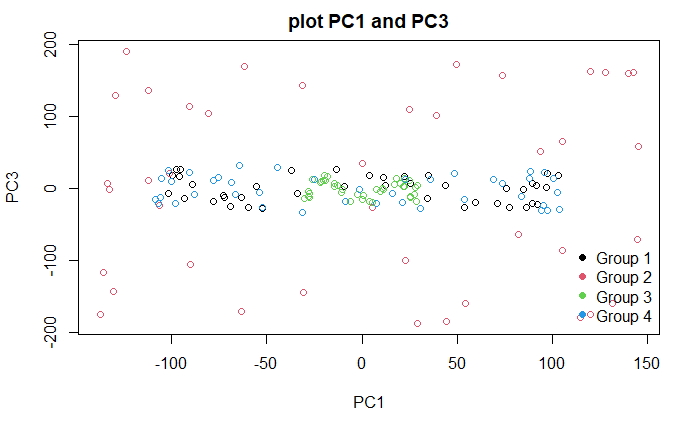

```r
TRANS2<-X%*%cbind(pca$rotation[,1],pca$rotation[,3])

plot(TRANS2[,1],
     TRANS2[,2],
     col = rep(1:4, each = 82),
     xlab="PC1",
     ylab="PC3",
     main = "plot PC1 and PC3")
legend("bottomright", legend = paste("Group", 1:4), col = 1:4, pch = 19, bty = "n")
```

8. [10 %] Nos han enviado nuevos datos (provenientes de 10 nuevas estructuras) y tenemos que decidir si cada uno de los datos pertenece a una estructura saludable o si tiene da~no.

Importar los datos que se encuentran en tower_data_new.mat y guardar el resultado en dataN (como habeis hecho con los datos del archivo data_tower_v42m.mat). Para acceder a los nuevos datos teneis que escribir dataN-Zs. Para proyectar los datos sobre el modelo que hemos generado en la pregunta 4, teneis primero que normalizar los datos respecto a los datos originales, es decir, a cada elemento de cada columna de la matriz dataN-Zs hay que restarle la media de todos los datos de la misma columna de la matriz data$Y. Hay que hacer lo mismo con la desviacion tiica, es decir, cada elemento de cada columna de la matriz dataN-Zs se ha de dividir por la desviacion tiica de todos los datos de la misma columna de la matriz data-Y. Llamar Z a la nueva matriz normalizada. Recordar que Z contiene 10 las y 58008 columnas.

Answer : We are going to SCALE the new matrix that we have in dataN$Z and save in Z. with center=TRUE, we are going subtract to each item the mean of its colum, with scale=TRUE we divide by its standard deviation to each result of the previous sentence. we print the previous and posterior data to the SCALE process, to see the differences.

```r
#We import the data new
dataN <- readMat ('TurbinesData/tower_data_new.mat')
dataN$Z[1:5,1:5]
```

```
             [,1]          [,2]          [,3]          [,4]          [,5]
[1,] 3.183557e-04  0.0002463096 -9.071952e-05  0.0002621842 -0.0001450594
[2,] 1.307568e-05  0.0005057976  1.168709e-04  0.0003104184  0.0002108971
[3,] 3.000389e-04 -0.0003245640  1.168709e-04 -0.0003795144  0.0005210616
[4,] 1.357982e-04  0.0001296926  1.235870e-04  0.0003891806  0.0001058808
[5,] 2.456990e-04  0.0003629266  1.003858e-04  0.0001699896  0.0001376299
```

```r
Z<-scale(dataN$Z,center  = TRUE,scale = TRUE)
Z[1:5,1:5]
```

```
           [,1]        [,2]        [,3]        [,4]        [,5]
[1,]  0.5322314  0.06995009 -1.22544091  0.09242365 -1.45992817
[2,] -1.0963837  1.14319150  0.20388983  0.26668304  0.51992324
[3,]  0.4345145 -2.29118102  0.20388983 -2.22588795  2.24507679
[4,] -0.4416804 -0.41237723  0.25013288  0.55123318 -0.06418386
[5,]  0.1446210  0.55227740  0.09038415 -0.24065442  0.11240666
```

9. [10 %] Proyectar los datos de la matriz Z sobre el espacio vectorial generado por las componentes principales mediante el producto matricial Z*pca-rotation. Llamar al resultado T. Comprobar que T es una matriz de 10 y 328 columnas.

Answer: We use the instruction to prove that matrix dimension is 10 by 328

```r
T<-Z%*%cbind(pca$rotation)
dim(T)
```

```
[1]  10 328
```

10. [10 %] Considerar vuestra fecha de nacimiento en la forma aammdd, por ejemplo 760827. Calcular, con R, lo siguiente 1 + aammdd % % 9 y llamar al resultado U. Recuperar el grafico bidimensional de la pregunta 6 (primera componente principal versus segunda componente principal) y anadir, uno a uno, los dos puntos de las las U y U+1. Para cada punto, vi- sualmente (por ejemplo, segun un criterio de proximidad), intentar clasicar, si podeis, las dos estructuras. A la vista del problema, proponer un metodo sistematico para clasificar de forma automatica un nuevo punto (pregunta abierta).

Answer : My proposal is use k-Nearest Neighbors Method, this classification method divides a training dataset into groups of k observations using a Euclidean Distance measure to determine similarity between “neighbors”. These classification groups are used to assign categories to each member of the validation training set.

```r
# We calculate U and show the value
U<-1 + 720930 %% 9
U
```

```
[1] 4
```

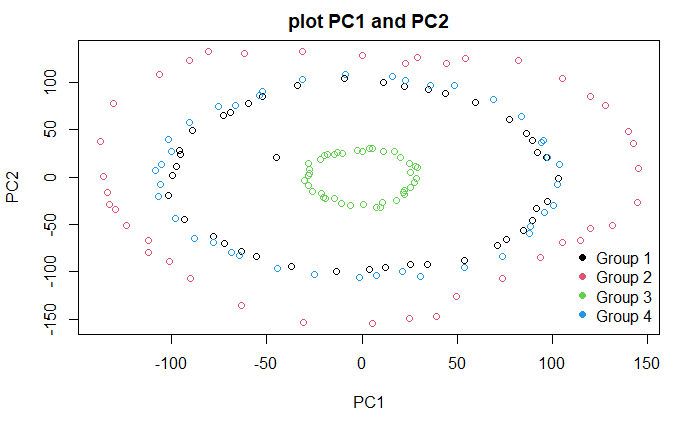

```r
#We add U and U+1 to TRANS from the 6 exercise
TFINAL<-rbind(TRANS,T[U,1:2])

#Show the graph
plot(TFINAL[,1],
     TFINAL[,2],
     col = rep(1:4, each = 82),
     xlab="PC1",
     ylab="PC2",
     main = "plot PC1 and PC2")
legend("bottomright", legend = paste("Group", 1:4), col = 1:4, pch = 19, bty = "n")
```

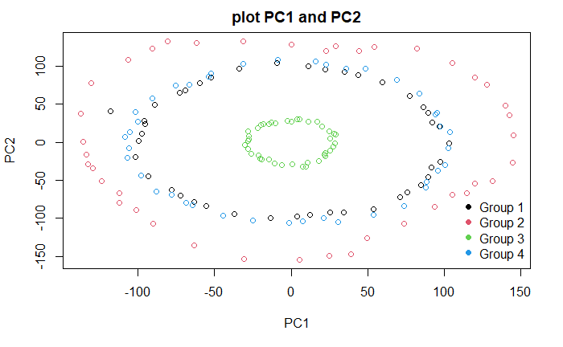

```r
#We add U+1 to TRANS from the 6 exercise
TFINAL<-rbind(TRANS,T[U+1,1:2])
#Show the graph
plot(TFINAL[,1],
     TFINAL[,2],
     col = rep(1:4, each = 82),
     xlab="PC1",
     ylab="PC2",
     main = "plot PC1 and PC2")
legend("bottomright", legend = paste("Group", 1:4), col = 1:4, pch = 19, bty = "n")
```